# Data Ingestion – Hierarchical Formats

Data science, machine learning, and statistics generally assume that data is tabular.

... but sometimes it isn't.

## XML

*XML is like violence—if it doesn’t solve your problems, you are not using enough of it.*

Anonymous

- Defining eXtensible Markup Language
- Dialects and schemata
- Attributes and elements
- Dealing with deep and ragged nesting

```
<?xml version="1.0" encoding="utf-8" ?>
<users>
  <user>
    <name>David Mertz</name>
    <password>badpassword</password>
    <details>
      <profession employer="KDM" duration="76" units="months">
      Data Scientist</profession>
      <telephone>+1 323 863 5571</telephone>
    </details>
    <lucky-numbers>
      <item>12</item>
      <item>42</item>
      <item>55</item>
      <item>87</item>
    </lucky-numbers>
  </user>
  <user> ... </user>
</users>
```

```python
import xml.etree.ElementTree as ET
tree = ET.parse('data/users.xml')

# Let us first find the attributes and text of a profession
prof = tree.find('user').find('details').find('profession')
print("Body (title):", prof.text.strip())
print("Attributes:  ", prof.attrib)
```

```
Body (title): Data Scientist
Attributes:   {'employer': 'KDM', 'duration': '76', 'units': 'months'}
```

```python
items = tree.find('user').find('lucky-numbers').findall('item')
lucky_numbers = [int(item.text) for item in items]
lucky_numbers
```

```
[12, 42, 55, 87]
```

```python
[int(el.text) for el in tree.iter() if el.tag == "item"]
```

```
[12, 42, 55, 87]
```

- `false`, `true`, and `null` are literal values
- An *object* is a grammatical structure that is enclosed in curly braces: `{` and `}`, with strings for keys, separated by a colon from values of any syntactic type. Multiple key/value pairs are separated by commas.
- An *array* is a grammatical structure that is enclosed in square brackets: `[` and `]`, with any syntactic values separated by commas.
- A *number* optionally starts with a minus sign, followed by a sequence of digits, optionally followed by a fractional part after a decimal portion, optionally followed by an exponent. This is mostly the same as the spelling of numbers in languages like Python, R, JavaScript, Julia, C, etc., but slightly more restrictive.
- A *string* is a grammatical structure enclosed by double quotes (the code point U+0022) that may contain almost any characters. Unicode code points may be indicated as e.g. `\u0022`, and a few special characters must be escaped with a backslash.

```
{"key": [true, false, null, 15, 55.66]}
```

```python
# A response to an HTTP request
response = requests.get('http://example.com/users')

# Show status code, content-type, and JSON body
print(response.status_code, response.headers['Content-Type'])
response.text
```

```
200 application/json; charset=utf-8
```

```
'{"1":{"name":"Guido van Rossum","password":"unladenswallow","details":{"profession":"ex-BDFL"}},"2":{"name":"Brendan Eich","password":"nontransitiveequality","details":{"profession":"Mozillan"}},"3":{"name":"Ken Thompson","password":"p/q2-q4!","details":{"profession":"Unix Creator"}}}'
```

```python
pprint_json(response.text)
```

```
{
  "1": {
    "name": "Guido van Rossum",
    "password": "unladenswallow",
    "details": {
      "profession": "ex-BDFL"
    }
  },
  "2": {
    "name": "Brendan Eich",
    "password": "nontransitiveequality",
    "details": {
      "profession": "Mozillan"
    }
  },
  "3": {
    "name": "Ken Thompson",
    "password": "p/q2-q4!",
    "details": {
      "profession": "Unix Creator"
    }
  }
}
```

```python
with open('data/users.json') as fh:
    # Could also call `json.load(fh)` to read file
    raw = fh.read()
    users = json.loads(raw)
users
```

```
{'1': {'name': 'Guido van Rossum',
  'password': 'unladenswallow',
  'details': {'profession': 'ex-BDFL'}},
 '2': {'name': 'Brendan Eich',
  'password': 'nontransitiveequality',
  'details': {'profession': 'Mozillan'}},
 '3': {'name': 'Ken Thompson',
  'password': 'p/q2-q4!',
  'details': {'profession': 'Unix Creator'}}}
```

[figure not shown]

### NaN Handling and Data Types

The semi-formal description of the grammar of JSON highlighted things *missing* from it.

There is a single syntactic type named "number", but there are no distinctions among integers, floating-point, decimals, complex numbers, fractions/rationals, or the bit-length of represented numbers.

There are also no IEEE-754 NaNs or infinities.

```python
# An interpreted float, an overflow, and a truncation
json_str = "[1e308, 1e309, 1.2345678901234567890]"
json.loads(json_str)
```

```
[1e+308, inf, 1.2345678901234567]
```

```python
simplejson.loads(json_str, use_decimal=True)
```

```
[Decimal('1E+308'), Decimal('1E+309'), Decimal('1.2345678901234567890')]
```

```python
specials = "[NaN, Infinity, -Infinity]"
vals = json.loads(specials)
vals
```

```
[nan, inf, -inf]
```

```python
%%bash
js="JSON.parse('[NaN, Infinity, -Infinity]');"
echo $js | node | cat
```

```
undefined:1
[NaN, Infinity, -Infinity]
 ^

SyntaxError: Unexpected token 'N', "[NaN, Infin"... is not valid JSON
    at JSON.parse (<anonymous>)
    at [stdin]:1:6
    at runScriptInThisContext (node:internal/vm:209:10)
    at node:internal/process/execution:118:14
    at [stdin]-wrapper:6:24
    at runScript (node:internal/process/execution:101:62)
    at evalScript (node:internal/process/execution:136:3)
    at node:internal/main/eval_stdin:32:5
    at Socket.<anonymous> (node:internal/process/execution:237:5)
    at Socket.emit (node:events:519:35)

Node.js v23.1.0
```

```python
json.loads("[NaN, Infinity, -Infinity]",
           parse_constant=lambda _: "INVALID")
```

```
['INVALID', 'INVALID', 'INVALID']
```

```python
try:
    json.loads("[nan, +Inf, Foobar]",
               parse_constant=lambda _: "INVALID")
except Exception as err:
    print_err(err)
```

```
JSONDecodeError
Expecting value: line 1 column 2 (char 1)
```

```python
%%bash
echo "[NaN, inf, -Infinity]" | jq .
```

```
[
  null,
  1.7976931348623157e+308,
  -1.7976931348623157e+308
]
```

### JSON Lines

Large aggregates of "small bundles of data" is in log files. The entries in log files are generally similar, and arranged one object per line.

Frequently different lines are required to hold different fields. This tends to require a lot of conditional logic when parsing a log file.

- Record separator-delimited: The Unicode character INFORMATION SEPARATOR TWO (U+001E) used as a delimiter (RFC 7464). I.e. newlines may occur inside JSON document entries.
- Concatenated JSON: No delimiters used, and each JSON entry is an object or array. This allows a streaming parser to recognize the matching `}` or `]` that will terminate the top-level structure. Every JSON Lines stream is automatically also a Concatenated JSON stream.
- Length-prefixed JSON: Each entry consists of an integer indicating the number of bytes in the remainder of the entry, followed by a JSON object or array (in principle, a string would work too). This has an advantage over plain concatenation in that the reader does not need to test on each character read whether a structure is completed.

```python
%%bash
# Extract registrations
grep "registered" data/jsonlines.log |
    sed 's/^.*registered"://' |
    sed 's/}.*/}/'
```

```
{"username":"bar","email":"bar@example.com"}
{"username":"baz","email":"baz@example.net"}
```

```python
%%bash
jq '.registered | select(.username != null)' data/jsonlines.log
```

```
{
  "username": "bar",
  "email": "bar@example.com"
}
{
  "username": "baz",
  "email": "baz@example.net"
}
```

```python
with open('data/jsonlines.log') as log:
    for line in log:
        record = json.loads(line)
        if 'registered' in record:
            user = record['registered']
            if 'username' in user:
                print(user)
```

```
{'username': 'bar', 'email': 'bar@example.com'}
{'username': 'baz', 'email': 'baz@example.net'}
```

### JSON Schema

One approach to enforcing assumptions about JSON documents is to use a JSON Schema to validate documents prior to passing them to data extraction functions.

Enforcing a schema is a good step towards assuring data integrity. Even if you, as a data scientist, need to reverse engineer one, that is often worthwhile for document types that are repeatedly processecd.

```python
user_schema = json.loads("""{
  "$schema": "http://json-schema.org/draft-07/schema#",
  "$id": "http://kdm.training/user-schema.json",
  "title": "User",
  "description": "A User of Our Computer System",
  "type" : "object",
  "required": ["name", "password"],
  "properties" : {
     "name" : {"type" : "string"},
     "password": {
         "description": "Use special characters and mixed case",
         "type": "string"},
     "lucky_numbers": {
         "description": "Up to 6 favorite numbers 1-100",
         "type": "array",
         "items": {
           "type": "number",
           "minimum": 1,
           "maximum": 100
         },
         "uniqueItems": true,
         "minItems": 0,
         "maxItems": 6
    }}}""")
```

```python
david = json.loads("""
{
  "name": "David Mertz",
  "password": "badpassword",
  "details": {
    "profession": "Data Scientist",
    "employer": "KDM"
  },
  "lucky_numbers": [12, 42, 55, 87]
}
""")

if msg := not_valid(david, user_schema):
    print(msg)
```

```python
barbara_feldon = json.loads("""
{
  "name": 99,
  "password": "1ibydieZ!S@8"
}
""")

if msg := not_valid(barbara_feldon, user_schema):
    print(msg)
```

```
99 is not of type 'string'

Failed validating 'type' in schema['properties']['name']:
    {'type': 'string'}

On instance['name']:
    99
```

```python
intruder = json.loads("""
{"password": "P4cC!^*8chWz8", "profession": "Hacker"}""")
msg = not_valid(intruder, user_schema)
msg_lines = msg.splitlines()
```

```python
print("\n".join(l.strip() for l in msg_lines))
```

```
'name' is a required property

Failed validating 'required' in schema:
{'$schema': 'http://json-schema.org/draft-07/schema#',
'$id': 'http://kdm.training/user-schema.json',
'title': 'User',
'description': 'A User of Our Computer System',
'type': 'object',
'required': ['name', 'password'],
'properties': {'name': {'type': 'string'},
'password': {'description': 'Use special characters '
'and mixed case',
'type': 'string'},
'lucky_numbers': {'description': 'Up to 6 favorite '
'numbers 1-100',
'type': 'array',
'items': {'type': 'number',
'minimum': 1,
'maximum': 100},
'uniqueItems': True,
'minItems': 0,
'maxItems': 6}}}

On instance:
{'password': 'P4cC!^*8chWz8', 'profession': 'Hacker'}
```

```python
the_count = json.loads("""
{
  "name": "Count von Count",
  "password": "fourbananas",
  "lucky_numbers": ["one", "two", "three"]
}
""")

if msg := not_valid(the_count, user_schema):
    print(msg, "\n--------------------")
```

```
'three' is not of type 'number'

Failed validating 'type' in schema['properties']['lucky_numbers']['items']:
    {'type': 'number', 'minimum': 1, 'maximum': 100}

On instance['lucky_numbers'][2]:
    'three'
--------------------
```

```python
georg = json.loads("""
{
  "name": "Georg Cantor",
  "password": "omega_aleph",
  "lucky_numbers": [1, 2, 3, 4, 5, 6, 7, 8]
}
""")

if msg := not_valid(georg, user_schema):
    print(msg)
```

```
[1, 2, 3, 4, 5, 6, 7, 8] is too long

Failed validating 'maxItems' in schema['properties']['lucky_numbers']:
    {'description': 'Up to 6 favorite numbers 1-100',
     'type': 'array',
     'items': {'type': 'number', 'minimum': 1, 'maximum': 100},
     'uniqueItems': True,
     'minItems': 0,
     'maxItems': 6}

On instance['lucky_numbers']:
    [1, 2, 3, 4, 5, 6, 7, 8]
```

```python
revolution_9 = json.loads("""
{
  "name": "Yoko Ono",
  "password": "grapefruit",
  "lucky_numbers": [9, 9, 9]
}
""")

if msg := not_valid(revolution_9, user_schema):
    print(msg)
```

```
[9, 9, 9] has non-unique elements

Failed validating 'uniqueItems' in schema['properties']['lucky_numbers']:
    {'description': 'Up to 6 favorite numbers 1-100',
     'type': 'array',
     'items': {'type': 'number', 'minimum': 1, 'maximum': 100},
     'uniqueItems': True,
     'minItems': 0,
     'maxItems': 6}

On instance['lucky_numbers']:
    [9, 9, 9]
```

## NoSQL Databases

- Graph databases
- Document-oriented databases
  - Missing fields in ragged documents
  - Denormalization and data integrity
- Key/value stores
  - Informal hierarchies

[figure not shown]

### Document-Oriented Databases

Document-oriented databases typically store and communicate their data using XML, YAML, JSON, or BSON (Binary JSON). In a sense, you can think of these databases simply as single giant files in one of these formats, which just happen to have mechanisms to index and optimize queries into them.

```python
# Assume that MongoDB is running on local system
from pymongo import MongoClient
client = MongoClient('mongodb://localhost:27017')
```

```python
# What databases exist on the local server?
client.list_database_names()
```

```
['admin', 'business', 'config', 'local']
```

A document-oriented database is typically organized as in a hierarchy:

server → database → collection → document.

A relational database is organized as:

server → database → table → row.

```python
db_biz = client.business
print("Collections:",
      [c['name'] for c in db_biz.list_collections()])
print("Number of restaurants:",
      db_biz.info.estimated_document_count())
print("Example:")
pprint(db_biz.info.find_one())
```

```
Collections: ['info', 'reviews']
Number of restaurants: 50
Example:
{'_id': ObjectId('67735c62e2becd6a79188b8d'),
 'cuisine': 'Mexican',
 'name': 'Kitchen Tasty Inc.',
 'phone': '+1 524 555 9265'}
```

```python
print("Reviews:", db_biz.reviews.estimated_document_count())

for review in db_biz.reviews.find(limit=3):
    pprint(review)
```

```
Reviews: 5000
{'_id': ObjectId('67735c62e2becd6a79188bbf'),
 'name': 'Goat Salty Take-Out',
 'price': 'expensive',
 'rating': 5}
{'_id': ObjectId('67735c62e2becd6a79188bc0'),
 'name': 'Big City Restaurant',
 'price': 'expensive',
 'rating': 2}
{'_id': ObjectId('67735c62e2becd6a79188bc1'),
 'name': 'Sweet Tasty Take-Out',
 'price': 'reasonable',
 'rating': 1}
```

```python
query = {'price': 'reasonable', 'name': 'Big City Restaurant'}
for review in db_biz.reviews.find(filter=query, limit=3):
    pprint(review)
```

```
{'_id': ObjectId('67735c62e2becd6a79188be4'),
 'name': 'Big City Restaurant',
 'phone': '+1 869 555 6412',
 'price': 'reasonable',
 'rating': 4}
{'_id': ObjectId('67735c62e2becd6a79188c18'),
 'name': 'Big City Restaurant',
 'price': 'reasonable',
 'rating': 7}
{'_id': ObjectId('67735c62e2becd6a79188c1c'),
 'name': 'Big City Restaurant',
 'price': 'reasonable',
 'rating': 7}
```

```python
no_rating = []
ratings = []
query = {'name': 'Big City Restaurant'}
for review in db_biz.reviews.find(filter=query):
    try:
        ratings.append(review['rating'])
    except KeyError:
        no_rating.append(f"{review['_id']}")
```

```
Missing rating:
 67735c62e2becd6a79188e76 67735c63e2becd6a791896aa 67735c63e2becd6a79189a2e
```

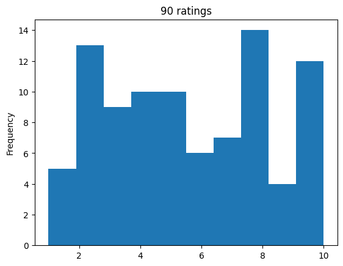

```python
n = len(ratings)
pd.Series(ratings).plot(kind="hist", title=f"{n} ratings")
print("Missing rating:\n", " ".join(no_rating))
```

```python
list(db_biz.reviews.find(
    filter={'name': 'Big City Restaurant', 'rating': None}))
```

```
[{'_id': ObjectId('67735c62e2becd6a79188e76'),
  'name': 'Big City Restaurant',
  'price': 'reasonable'},
 {'_id': ObjectId('67735c63e2becd6a791896aa'),
  'name': 'Big City Restaurant',
  'price': 'expensive'},
 {'_id': ObjectId('67735c63e2becd6a79189a2e'),
  'name': 'Big City Restaurant',
  'price': 'reasonable'}]
```

#### Denormalization and Its Discontents

For performance reasons that are analogous to those in relational databases, sometimes data is denormalized in document-oriented databases. Querying within one branch will be faster, and querying just one document will be much faster again. Hence, administrators of document-oriented databases will commonly duplicate information into a location "closer" to where it is typically accessed.

```python
def has_best_review(name, db=db_biz):
    "Return phone if restaurant has at least one 10 rating"
    query = {'name': name, 'rating': 10}
    review = None

    # Fast path has phone in local results
    for review in db.reviews.find(query):
        phone = review.get('phone')
        if phone:
            return f"Call {name} at {phone}! (FAST query)"

    # If there were no ratings of 10, we don't like it!
    if not review:
        return f"Do not bother with {name}!"

    # MUCH SLOWER path is second query
    info = db.info.find_one({'name': name})
    return f"Call {name} at {info['phone']}! (SLOW query)"
```

```python
has_best_review('Kitchen Tasty Inc.')
```

```
'Call Kitchen Tasty Inc. at +1 524 555 9265! (FAST query)'
```

```python
has_best_review('City Kitchen Inc.')
```

```
'Do not bother with City Kitchen Inc.!'
```

```python
has_best_review('Sweet Tasty Take-Out')
```

```
'Call Sweet Tasty Take-Out at +1 759 555 0158! (SLOW query)'
```

### Key/Value Stores

The simplest possible database system is a key/value store. These systems do nothing more than map some key (usually a string) to a value (sometimes a string, sometimes compound types).

To illustrate this caching in pseudo-code, a server proxy might contain code similar to this:

```
request = get_client_request()
key = hash(request)   # Collision resistant hash

# See if FAST PATH is available
if result := check_for_cache(key):
    send_to_client(result)

# SLOW PATH as fallback
else:
    result = expensive_operation(request)
    send_to_client(result)
    store_to_cache(key, result, expiration=duration)
```

```python
biz = dbm.open('data/keyval.db')
seed(6)
# Keys are bytes; could convert to strings if desired
sample(list(biz.keys()), 10)
```

```
[b'Big Sweet Take-Out::info::phone',
 b'Big Sweet Inc.::ratings',
 b'Goat Sweet Inc.::info::phone',
 b'Fish City Restaurant//ratings',
 b'Delight Goat Inc.::ratings',
 b'DESCRIPTION',
 b'Salty Delight Take-Out::ratings',
 b'Sweet Tasty Restaurant::info::phone',
 b'Delight Salty Restaurant::info::phone',
 b'Tasty Fish Inc.::info::cuisine']
```

```python
name = b"Tasty Fish Inc."
print("Overview:", biz[b"DESCRIPTION"])
print("Cuisine: ", biz[name + b"::info::cuisine"] )
print("Ratings: ", biz[name + b"::ratings"][:30], "...")
```

```
Overview: b'Restaurant information'
Cuisine:  b'Mexican'
Ratings:  b'2;1;1;10;5;7;1;4;8;10;7;7;6;8;' ...
```

```python
for key, val in biz.items():
    if key.startswith(b'Tasty Fish Inc.::'):
        print(key.decode(), '\t', val[:30].decode())
```

```
Tasty Fish Inc.::ratings 	 2;1;1;10;5;7;1;4;8;10;7;7;6;8;
Tasty Fish Inc.::info::phone 	 +1 935 555 8029
Tasty Fish Inc.::info::cuisine 	 Mexican
```

```python
for key, val in biz.items():
    if key.startswith(b'Fish City Restaurant'):
        print(key, val[:30])
```

```
b'Fish City Restaurant::ratings' b'6;10;4;3;10;5;1;4;7;8;5;2;1;5;'
b'Fish City Restaurant//ratings' b'9'
b'Fish City Restaurant::info::phone' b'+1 851 555 1082'
b'Fish City Restaurant::info::cuisine' b'American'
```

## Denouement

> Simple is better than complex.  
> Complex is better than complicated.  
> Flat is better than nested.  
> Sparse is better than dense.  
> Readability counts.  
> –Tim Peters (The Zen of Python)